# Occitanica : documents libres, sélection du 6 novembre 2026

Essai local, non publié. Chaque carte renvoie à la fiche d’origine sur occitanica.eu. Mention « domaine public » telle que l’écrit le CIRDÒC (à confirmer avant toute reprise).

## Godolin en images (lithographies de 1843)

[figure not shown]

**Portrait / Perrin del. ; imp. par Belquin ; lith. Delor à Toulouse**Perrin, Olivier Stanislas ( 1761-1832). Dessinateur. 1843Domaine public · 1 Mo

[figure not shown]

[figure not shown]

[figure not shown]

**Clémence-Isaure/ Perrin del. ; imp. par Belquin ; lith. Delor à Toulouse**Perrin, Olivier Stanislas ( 1761-1832). Dessinateur. 1843Domaine public

[figure not shown]

[figure not shown]

**Chalette peignant Godoli / Perrin del. ; imp. par Belquin ; lith. Delor à Toulouse**Perrin, Olivier Stanislas ( 1761-1832). Dessinateur. 1843Domaine public

## Images d’histoire

[figure not shown]

**Instauration des Jeux floraux à Toulouse le 3 mai 1324 / peinture de Jean-Paul Laurens**Laurens, Jean-Paul (1838-1921) 1912Domaine public · 1 Mo

[figure not shown]

**Portrait de Junior Sans, félibre majoral / par Frère Sénateur**Frère Sénateur Martin 1885Domaine public · 29 Mo

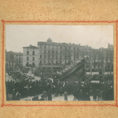

**[Photographies : Corso ou cavalcade du Carnaval de Béziers (vers 1900)]** 1900Domaine public · 65 Mo

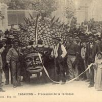

**Tarascon : procession de la Tarasque** [19..]Domaine public

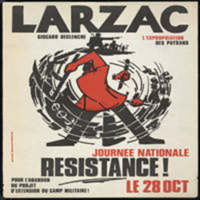

**Larzac : Giscard déclenche l'expropriation des paysans : Journée nationale Résistance !** 1971-1981Domaine public · 7 Mo

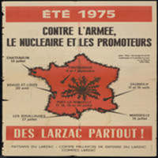

## Chants et partitions

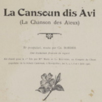

**La Cansoun dis Avi = La chanson des aïeux / F. Mistral ; Èr poupulàri, nouta pèr Ch. Borde**Mistral, Frédéric (1830-1914) 1906Domaine public · 3 Mo

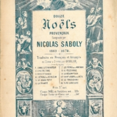

[figure not shown]

[figure not shown]

**Airs populaires provençaux adaptés aux cantilènes de la Reine Jeanne / Frédéric Mistral**Mistral, Frédéric (1830-1914) 1921Domaine public · 1 Mo

[figure not shown]

[figure not shown]

## Textes fondateurs et anciens

[figure not shown]

[figure not shown]

**Obros et rimos provenssalos de Loys de La Bellavdiero, Gentilhomme Prouuenssau. Reviovdado**Bellaud de la Bellaudière, Louis (1533?-1588) 1595Domaine public · 270 Mo

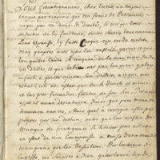

**[L'opera de Frountignan / Nicolas Fizes]**Fizes, Nicolas (1648-1718) 1705Domaine public/Domeni public · 13 Mo

[figure not shown]

**Le fouet de carnabal : satiros / [attribué à Louis Vestrepain]**Vestrepain, Louis (1809-1865) 1841Domaine public · 30 Mo

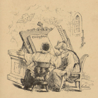

## Revues et almanachs

[figure not shown]

**Lo Gai Saber : revista de l'Escòla occitana**Estieu, Prosper (1860-1939). Directeur de publication ; Salv 1919-Domaine Public

[figure not shown]

**L'Aiòli : que vai cremant tres fes pèr mes / baile dóu journau : Folcò de Baroncelli**Baroncelli, Folco de (1869-1943). Directeur de la publicatio 1891/1932domaine Public

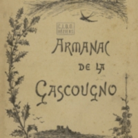

**Almanac de la Gascougno**Sarran, Fernand (1876-1928) ; Médan, Léopold (1883-1960) 1898-1959Domaine Public

[figure not shown]

**Almanac narbounes**Cigalo Narbouneso 1913-1914 ; 1923-1932 ; 1937Domaine Public

[figure not shown]

**Reclams de Biarn e Gascougne / Escole Gastou Febus**Escole Gastou-Febus. Éditeur scientifique 1897/....domaine public · 1 Mo

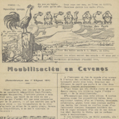

**Cacalaca : Soulas del pople Cevenòu**Castagno, Jan (1859-1938) 1916-1936domaine public · 5 Mo

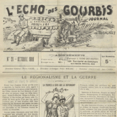

**L'Echo des Gourbis**Lafforgue, Jules (18..-1947) ; Malzac, Franc ; Cazes, Jean 1916domaine public · 4 Mo

## Sons

[figure not shown]

**Dançarèla / émission présentée par Bruno Cécillon avec la collaboration de Henri Turlan** 1991Domaine public

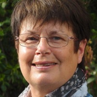

**La Cronica etnobotanica / présentée par Josiane Ubaud, co-animée par Aimé Brees**Ubaud, Josiane Brees, Aimé 2006Domaine public

[figure not shown]

**À propos du fonds du Teatre de la Carrièra / Catherine Bonafé**Bonafé, Catherine 2016Domaine public/Domeni public

## Fiches de l’encyclopédie

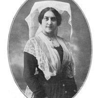

**Je recherche la biographie de la conteuse limousine, Marguerite Priolo.**Lo CIRDÒC-Mediatèca occitana 2012Domaine public

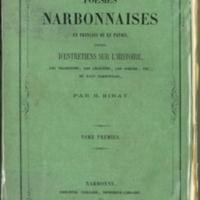

**HERCULE BIRAT (1796-1872), biographie**Centre inter-régional de développement de l'occitan (Béziers 2012Domaine public / Domeni public · 1 Mo

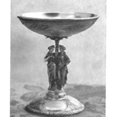

**I troubaïre catalan**CIRDÒC - Mediatèca occitana 2014-03-24Domaine public/Domeni public

[figure not shown]

**Trobairitz en Gévaudan**Centre inter-régional de développement de l'occitan (Béziers 2014-09-25Domaine public / Domeni public

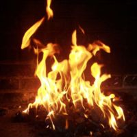

**Halhas et soca de Nadau**Lo CIRDOC-Mediatèca occitana 2012Domaine public

## Patrimoine immatériel

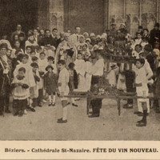

**La fête des Caritats racontée par le Baron de Bonnefoux**Bonnefoux, Pierre-Marie-Joseph de (Bon) (1782-1855) ; Jobbé- 1900Domaine public

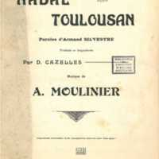